# exam 3

carter

2025-12-04

#Chunk 1 - setup and browsing

```r
library(tidyverse)
fac <- read.csv("FacultySalaries_1995.csv")
glimpse(fac)
```

```
## Rows: 1,161
## Columns: 17
## $ FedID               <int> 1061, 1063, 1065, 11462, 1002, 1004, 1008, 1009, 1…
## $ UnivName            <chr> "Alaska Pacific University", "Univ.Alaska-Fairbank…
## $ State               <chr> "AK", "AK", "AK", "AK", "AL", "AL", "AL", "AL", "A…
## $ Tier                <chr> "IIB", "I", "IIA", "IIA", "IIA", "IIA", "IIB", "I"…
## $ AvgFullProfSalary   <int> 454, 686, 533, 612, 442, 441, 466, 580, 498, 506, …
## $ AvgAssocProfSalary  <int> 382, 560, 494, 507, 369, 385, 394, 437, 379, 412, …
## $ AvgAssistProfSalary <int> 362, 432, 329, 414, 310, 310, 351, 374, 322, 359, …
## $ AvgProfSalaryAll    <int> 382, 508, 415, 498, 350, 388, 396, 455, 401, 411, …
## $ AvgFullProfComp     <int> 567, 914, 716, 825, 530, 542, 558, 692, 655, 607, …
## $ AvgAssocProfComp    <int> 485, 753, 663, 681, 444, 473, 476, 527, 501, 508, …
## $ AvgAssistProfComp   <int> 471, 572, 442, 557, 376, 383, 427, 451, 404, 445, …
## $ AvgProfCompAll      <int> 487, 677, 559, 670, 423, 477, 478, 546, 523, 503, …
## $ NumFullProfs        <int> 6, 74, 9, 115, 59, 57, 20, 366, 34, 67, 8, 106, 27…
## $ NumAssocProfs       <int> 11, 125, 26, 124, 77, 33, 18, 354, 25, 40, 15, 42,…
## $ NumAssistProfs      <int> 9, 118, 20, 101, 102, 35, 30, 301, 27, 66, 19, 66,…
## $ NumInstructors      <int> 4, 40, 9, 21, 24, 2, 0, 66, 3, 27, 2, 58, 4, 19, 3…
## $ NumFacultyAll       <int> 32, 404, 70, 392, 262, 127, 68, 1109, 89, 200, 44,…
```

```r
head(fac)
```

```
##   FedID                  UnivName State Tier AvgFullProfSalary
## 1  1061 Alaska Pacific University    AK  IIB               454
## 2  1063     Univ.Alaska-Fairbanks    AK    I               686
## 3  1065     Univ.Alaska-Southeast    AK  IIA               533
## 4 11462     Univ.Alaska-Anchorage    AK  IIA               612
## 5  1002 Alabama Agri.&Mech. Univ.    AL  IIA               442
## 6  1004  University of Montevallo    AL  IIA               441
##   AvgAssocProfSalary AvgAssistProfSalary AvgProfSalaryAll AvgFullProfComp
## 1                382                 362              382             567
## 2                560                 432              508             914
## 3                494                 329              415             716
## 4                507                 414              498             825
## 5                369                 310              350             530
## 6                385                 310              388             542
##   AvgAssocProfComp AvgAssistProfComp AvgProfCompAll NumFullProfs NumAssocProfs
## 1              485               471            487            6            11
## 2              753               572            677           74           125
## 3              663               442            559            9            26
## 4              681               557            670          115           124
## 5              444               376            423           59            77
## 6              473               383            477           57            33
##   NumAssistProfs NumInstructors NumFacultyAll
## 1              9              4            32
## 2            118             40           404
## 3             20              9            70
## 4            101             21           392
## 5            102             24           262
## 6             35              2           127
```

#Chunk 2 - to tidy data and checking

```r
fac_tidy <- fac %>%
  pivot_longer(
    cols = c(AvgAssistProfSalary, AvgAssocProfSalary, AvgFullProfSalary),
    names_to = "Rank",
    values_to = "Salary"
  ) %>%
  mutate(
    Rank = recode(Rank,
                  "AvgAssistProfSalary" = "Assist",
                  "AvgAssocProfSalary"  = "Assoc",
                  "AvgFullProfSalary"   = "Full"),
    Rank = factor(Rank, levels = c("Assist", "Assoc", "Full"))
  )
glimpse(fac_tidy)
```

```
## Rows: 3,483
## Columns: 16
## $ FedID             <int> 1061, 1061, 1061, 1063, 1063, 1063, 1065, 1065, 1065…
## $ UnivName          <chr> "Alaska Pacific University", "Alaska Pacific Univers…
## $ State             <chr> "AK", "AK", "AK", "AK", "AK", "AK", "AK", "AK", "AK"…
## $ Tier              <chr> "IIB", "IIB", "IIB", "I", "I", "I", "IIA", "IIA", "I…
## $ AvgProfSalaryAll  <int> 382, 382, 382, 508, 508, 508, 415, 415, 415, 498, 49…
## $ AvgFullProfComp   <int> 567, 567, 567, 914, 914, 914, 716, 716, 716, 825, 82…
## $ AvgAssocProfComp  <int> 485, 485, 485, 753, 753, 753, 663, 663, 663, 681, 68…
## $ AvgAssistProfComp <int> 471, 471, 471, 572, 572, 572, 442, 442, 442, 557, 55…
## $ AvgProfCompAll    <int> 487, 487, 487, 677, 677, 677, 559, 559, 559, 670, 67…
## $ NumFullProfs      <int> 6, 6, 6, 74, 74, 74, 9, 9, 9, 115, 115, 115, 59, 59,…
## $ NumAssocProfs     <int> 11, 11, 11, 125, 125, 125, 26, 26, 26, 124, 124, 124…
## $ NumAssistProfs    <int> 9, 9, 9, 118, 118, 118, 20, 20, 20, 101, 101, 101, 1…
## $ NumInstructors    <int> 4, 4, 4, 40, 40, 40, 9, 9, 9, 21, 21, 21, 24, 24, 24…
## $ NumFacultyAll     <int> 32, 32, 32, 404, 404, 404, 70, 70, 70, 392, 392, 392…
## $ Rank              <fct> Assist, Assoc, Full, Assist, Assoc, Full, Assist, As…
## $ Salary            <int> 362, 382, 454, 432, 560, 686, 329, 494, 533, 414, 50…
```

```r
head(fac_tidy)
```

```
## # A tibble: 6 × 16
##   FedID UnivName   State Tier  AvgProfSalaryAll AvgFullProfComp AvgAssocProfComp
##   <int> <chr>      <chr> <chr>            <int>           <int>            <int>
## 1  1061 Alaska Pa… AK    IIB                382             567              485
## 2  1061 Alaska Pa… AK    IIB                382             567              485
## 3  1061 Alaska Pa… AK    IIB                382             567              485
## 4  1063 Univ.Alas… AK    I                  508             914              753
## 5  1063 Univ.Alas… AK    I                  508             914              753
## 6  1063 Univ.Alas… AK    I                  508             914              753
## # ℹ 9 more variables: AvgAssistProfComp <int>, AvgProfCompAll <int>,
## #   NumFullProfs <int>, NumAssocProfs <int>, NumAssistProfs <int>,
## #   NumInstructors <int>, NumFacultyAll <int>, Rank <fct>, Salary <int>
```

##Task 1 - a plot, showing salary plots by rank

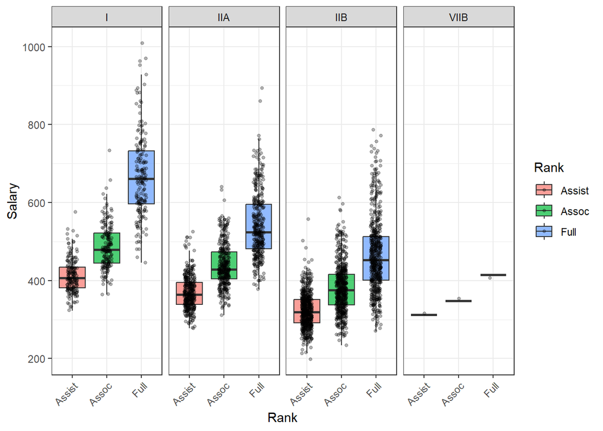

```r
fac_tidy %>%
  ggplot(aes(x = Rank, y = Salary, fill = Rank)) +
  geom_boxplot(outlier.shape = NA, alpha = 0.7) +
  geom_jitter(width = 0.15, alpha = 0.3, size = 1) +
  facet_grid(~ Tier) +
  labs(x = "Rank", y = "Salary") +
  theme_bw() +
  theme(axis.text.x = element_text(angle = 45, hjust = 1))
```

```r
anova_mod <- aov(Salary ~ State + Tier + Rank, data = fac_tidy)
summary(anova_mod)
```

```
##               Df   Sum Sq Mean Sq F value Pr(>F)
## State         51  5682396  111420   30.66 <2e-16 ***
## Tier           2  7072361 3536180  972.96 <2e-16 ***
## Rank           2 16529771 8264885 2274.04 <2e-16 ***
## Residuals   3299 11990072    3634
## ---
## Signif. codes:  0 '***' 0.001 '**' 0.01 '*' 0.05 '.' 0.1 ' ' 1
## 128 observations deleted due to missingness
```

##Task 3 - Juniper Oils - I tidied the Juniper_Oils data by pivoting all chemical concentration columns into a long format, creating a compound column with the chemical name and a concentration column with its measured value.

```r
juniper <- read_csv("Juniper_Oils.csv")
glimpse(juniper)
```

```
## Rows: 34
## Columns: 41
## $ SampleID               <chr> "LOG-16S-SL12", "LOG-16S-SL11", "LOG-16S-CC5", …
## $ Project                <chr> "JuniperLogs", "JuniperLogs", "JuniperLogs", "J…
## $ Amplicon               <chr> "16S", "16S", "16S", "16S", "16S", "16S", "16S"…
## $ Tree_Species           <chr> "Juniperus osteosperma", "Juniperus osteosperma…
## $ BurnYear               <dbl> 2018, 2017, 2016, 2014, 2013, 2012, 2011, 2009,…
## $ Latitude               <dbl> 41.5719, 40.9202, 37.5799, 39.9422, 41.5335, 40…
## $ Longitude              <dbl> -113.7488, -113.0017, -113.0851, -112.7181, -11…
## $ Field_Office           <chr> "Salt_Lake_3", "Salt_Lake_2", "Cedar_City", "Sa…
## $ BLM_Fire_Name          <chr> "Ridge", "Knob", "Hicks Creek", "Lion Peak", "P…
## $ Tracking_Number        <chr> "#5276 (2018)", "#5275 (2017)", "#5274 (2016)",…
## $ `alpha-pinene`         <dbl> 0.6, 1.4, 0.2, 0.3, 0.1, 0.0, 0.1, 0.2, 0.1, 0.…
## $ `para-cymene`          <dbl> 0.4, 0.3, 1.1, 0.1, 0.1, 0.1, 0.5, 0.6, 0.2, 0.…
## $ `alpha-terpineol`      <dbl> 2.3, 0.5, 0.8, 0.7, 0.2, 0.1, 2.8, 1.1, 0.1, 0.…
```

[output cut: 28 more lines]

```r
chem_cols <- c("alpha-pinene","para-cymene","alpha-terpineol","cedr-9-ene",
               "alpha-cedrene","beta-cedrene","cis-thujopsene",
               "alpha-himachalene","beta-chamigrene","cuparene","compound 1",
               "alpha-chamigrene","widdrol","cedrol","beta-acorenol",
               "alpha-acorenol","gamma-eudesmol","beta-eudesmol",
               "alpha-eudesmol","cedr-8-en-13-ol","cedr-8-en-15-ol",
               "compound 2","thujopsenal")
juniper_tidy <- juniper %>%
  pivot_longer(
    cols = all_of(chem_cols),
    names_to = "Compound",
    values_to = "Concentration"
  )
```

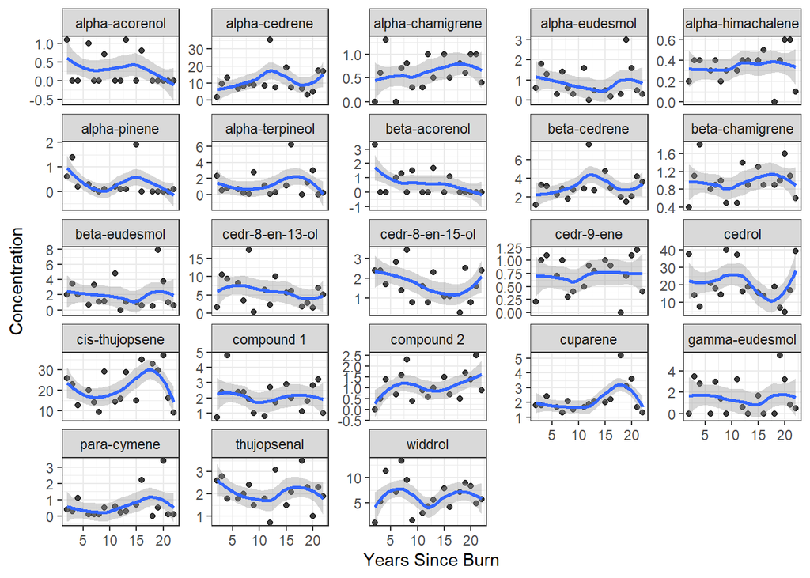

```r
juniper_tidy %>%
  ggplot(aes(x = YearsSinceBurn, y = Concentration)) +
  geom_point(alpha = 0.5) +
  geom_smooth(method = "loess", se = TRUE) +
  facet_wrap(~ Compound, scales = "free_y") +
  labs(x = "Years Since Burn", y = "Concentration") +
  theme_bw()
```

```r
head(juniper_tidy)
```

```
## # A tibble: 6 × 20
##   SampleID     Project     Amplicon Tree_Species     BurnYear Latitude Longitude
##   <chr>        <chr>       <chr>    <chr>               <dbl>    <dbl>     <dbl>
## 1 LOG-16S-SL12 JuniperLogs 16S      Juniperus osteo…     2018     41.6     -114.
## 2 LOG-16S-SL12 JuniperLogs 16S      Juniperus osteo…     2018     41.6     -114.
## 3 LOG-16S-SL12 JuniperLogs 16S      Juniperus osteo…     2018     41.6     -114.
## 4 LOG-16S-SL12 JuniperLogs 16S      Juniperus osteo…     2018     41.6     -114.
## 5 LOG-16S-SL12 JuniperLogs 16S      Juniperus osteo…     2018     41.6     -114.
## 6 LOG-16S-SL12 JuniperLogs 16S      Juniperus osteo…     2018     41.6     -114.
## # ℹ 13 more variables: Field_Office <chr>, BLM_Fire_Name <chr>,
## #   Tracking_Number <chr>, Yield_percent <dbl>, Bolt_Surface_Area_cm2 <dbl>,
## #   Raw_Exit_Holes_per_cm2 <dbl>, Raw_Exit_Holes <dbl>, Living_Larvae <dbl>,
## #   ChemTotal <dbl>, ChemMean <dbl>, YearsSinceBurn <dbl>, Compound <chr>,
## #   Concentration <dbl>
```

##Task 5 - GLM. I fit separate generalized linear models for each chemical, using Concentration as the response and YearsSinceBurn as the predictor. I used `broom::tidy()` to extract coefficients and then filtered for the YearsSinceBurn term with p < 0.05. The resulting table shows which chemical concentrations are significantly affected by time since burn.

```r
library(broom)
library(dplyr)

# Get list of all compounds
compounds <- unique(juniper_tidy$Compound)

# Fit a glm for each compound and store results
res_list <- lapply(compounds, function(cmp) {
  dat <- juniper_tidy %>% filter(Compound == cmp)

  # fit GLM (gaussian family ~ same as linear model)
  m <- glm(Concentration ~ YearsSinceBurn, data = dat, family = gaussian())

  # tidy the model output and add the compound name as a column
  tidy(m) %>%
    mutate(Compound = cmp)
})

# Combine all results into one data frame
glm_results <- bind_rows(res_list)

# Keep only significant YearsSinceBurn terms
glm_sig <- glm_results %>%
  filter(term == "YearsSinceBurn",
         p.value < 0.05) %>%
  arrange(p.value)

glm_sig
```

```
## # A tibble: 3 × 6
##   term           estimate std.error statistic p.value Compound
##   <chr>             <dbl>     <dbl>     <dbl>   <dbl> <chr>
## 1 YearsSinceBurn  -0.0655    0.0226     -2.90 0.00664 beta-acorenol
## 2 YearsSinceBurn   0.0550    0.0244      2.26 0.0310  cuparene
## 3 YearsSinceBurn   0.0356    0.0173      2.06 0.0471  compound 2
```